# Tvyal Newsletter

2024-12-30

**Հարգելի գործընկեր,**

## **Շնորհավոր Ամանոր և Սուրբ Ծնունդ**

## **Merry Christmas & Happy New Year**

🎄🎅🎁✨🔔🕯️🦌🎉🍪🥛⛄🌨️🧤🧣🍬🍭

Շնորհակալ եմ որ հետևում եք մեր գործունեությանը ([կայքի հղումը](https://www.tvyal.com/newsletter/2024/2024_12_30))

Thanks for your time and for hanging with us ([link to the website](https://www.tvyal.com/newsletter/2024/2024_12_30))

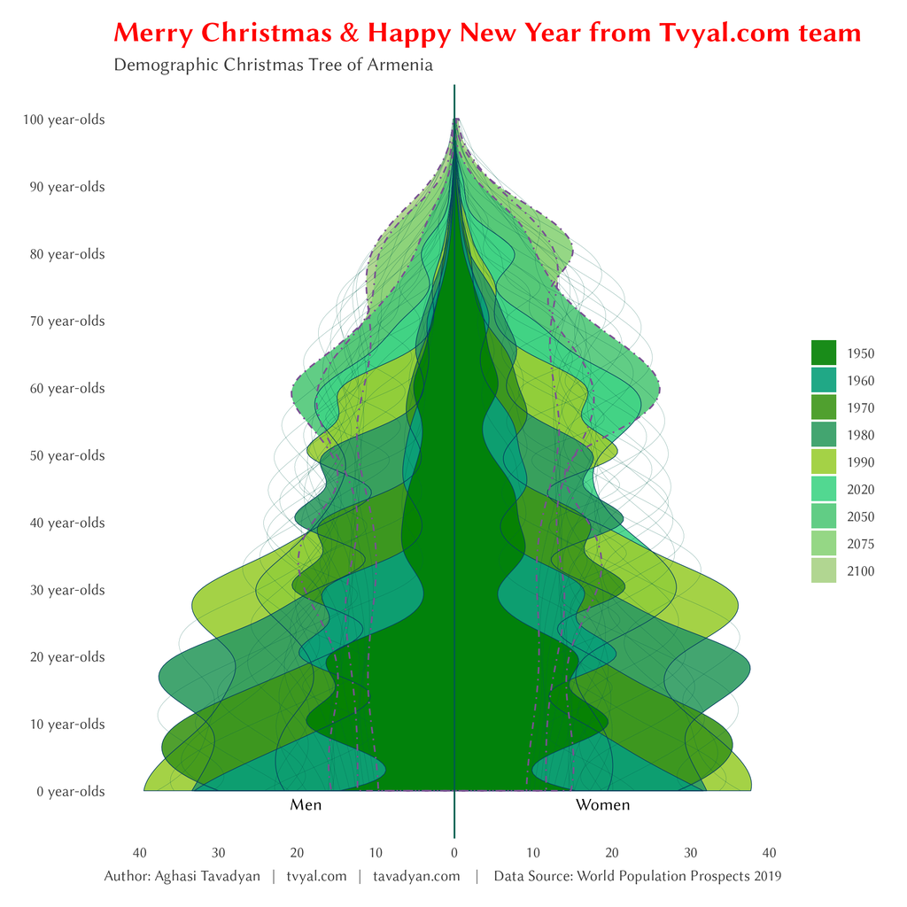

Երկու խոսք գծապատկեր-բացիկի մասին։ Գծապատկերը ՀՀ դեմոգրաֆիկ ծառն է՝ 1950 թվականից սկսած մինչև 2100 թվականի կանխատեսումը` ներկայացված որպես տոնածառ։

### *Թող 2025 թվականը բացի նոր հնարավորությունների և հաջողությունների դռներ Ձեր առջև։*

## Ամփոփենք տարին

Այս տարվա ընթացքում մենք ստեղծել ենք․

- [ավելի քան 45 վերլուծություն](https://www.tvyal.com/newsletter) ⏳
- [ավելի քան 16 հազար տող կոդ](https://github.com/tavad/tvyal_newsletter/tree/main/2024) 💻
- ավելի քան 200 գծապատկեր 📊
- 1950 էլ փոստ բաժանորդագրվածների ցանկում, նախորդ տարվա վերջի 950-ի համեմատ 📬
- Ավելի քանի 75 ԶԼՄ հաղորդակցություն

## Let’s Summarize the Year

This year we have created:

- [more than 45 analyses](https://www.tvyal.com/newsletter) ⏳
- [more than 16 thousand lines of code](https://github.com/tavad/tvyal_newsletter/tree/main/2024) 💻
- more than 200 charts 📊
- 1950 subscribers in the mailing list, compared to 950 at the end of last year 📬
- More than 75 media communications

## *Ապագա պլաններ*

Մեր թիմը նպատակադրված է առաջիկա տարվա ընթացքում հասնել հետևյալ նպատակներին․

1. Կայքի ամբողջական թարմացում։ Անգլերեն և ռուսերեն լեզուների լիարժեք ընդգրկում։ Քոմենթների և ինտերակտիվ այլ համակարգերի ներդնում։
2. [tvyal.com](https://www.tvyal.com/) հարթակը պլանավորում ենք դարձնել բոլոր հայկական (և ոչ միայն) տվյալների նորմալիզացված պորտալը, որտեղ հիմնականում անվճար նորմալիզացված տվյալներ հնարավոր կլինի ներբեռնել նաև API-ով, որը հետագայում հասանելի կլինի JS, Python, R և այլ լեզուների գրադարաններում։ Նշեմ, որ Armstat, CBA, cadastre.am և այլ պորտալների կողմից տրամադրվող տվյալները խառն են և չունեն ստանդարտիզացված կառուցվածք, տվյալներից շատերը PDF ֆորմատով են կամ ամսական տրվող առանձին աղյուսակներում, որոնք անհրաժեշտ է մաքրել և միավորել ժամանակային շարք ստանալու համար։ Բոլոր տվյալները պետք է ունենան նորմալիզացված, մաքուր տեսք:
- Նշենք, որ [tvyal.com](https://www.tvyal.com/) հարթակն իր գործունեությամբ արդեն իսկ այդ տվյալներից շատերի ավտոմատիզացված ներբեռնումը, մաքրումը և նորմալիզացված տվյալների բազա ստեղծելը կատարել է։ Տվյալների 70-90 տոկոսը հարթակում անվճար է լինելու։
3. Պլանավորվում է շարունակել շաբաթական անվճար վերլուծությունները։ Սակայն ապագայում դրվելու է վերլուծության հիմնական մասը։ Որոշ զգայուն վերլուծություններ կամ վերլուծությունների ավելի խորը ներկայացումը վճարովի է լինելու։ Ամենայն հավանականությամբ գրանցումով ու ամսական վճարով, որը նաև ներառելու է նախորդ կետում նշած բոլոր տվյալներից API-ով օգտվելու հնարավորությունը։
4. Պլանների մեջ կա նաև փոխարժեքի տվյալների լիարժեք ներկայացումը։ Արդեն 1 տարի է, ինչ մենք ավտոմատիզացված ստանում ենք այդ տվյալները։ Պլանավորվում է գրաֆիկական ներկայացում դնել փոխարժեքի վերջին բոլոր տվյալների։
5. Պլանավորվում է մեծացնել ստորաբաժանումը, որը զբաղված կլինի հայկական ու այլ պետությունների կազմակերպությունների տվյալների մշակմամբ, համակարգմամբ, դրանցից արժեք քաղելով, ավտոմատիզացմամբ, կանխատեսմամբ և այլն։

# ՀԱՄԱԳՈՐԾԱԿՑՈՒԹՅՈՒՆ

## Եթե ուզում եք AI գործիքներով ձեր տվյալներից օգուտ քաղել` ԴԻՄԵՔ ՄԵԶ

### Մենք առաջարկում ենք

- Extensive databases for finding both international and local leads
- Exclusive reports on the Future of the Armenian Economy
- Work and browser automation to streamline operations and reduce staffing needs
- AI models for forecasting growth and optimizing various aspects of your business
- Advanced dashboarding and BI solutions
- Algorithmic trading

### Let’s Put Your Data to Work!

### ՄԻԱՑԵՔ ՄԵՐ ԹԻՄԻՆ

## ԶԼՄ հաղորդագրություններ

[Դիտեք 1in.am-ին տված իմ վերջին հարցազրույցը, որտեղ ամփոփում եմ 2024-ը։](https://www.youtube.com/watch?v=FqSxs6Hypp4&t=11s)

Հարցազրույցում շոշափվել են հետևյալ թեմաները։

- 🎯 Ո՞րն է մեր տնտեսության զարգացման իրական ուղղությունը արդեն 20 տարի։
- 🎯 Ինչո՞վ է թերի մեր հարկային համակարգը։
- 🎯 Ինչպե՞ս ուժեղացավ Ռուսաստանի ազդեցությունը Հայաստանի տնտեսության վրա։
- 🎯 Ի՞նչ սպասել 2025 թվականին։

[figure not shown]

Եթե հնարավոր է, խնդրում եմ այս նյութը ուղարկել նաև այն մարդկանց, ում այն կարծում եք կարող է հետաքրքրել:

Սպասեք հաջորդ հաղորդագրությանը մի շաբաթվա ընթացքում:

Հարգանքներով,  
Աղասի Թավադյան  
30.12.2024  
[tvyal.com](https://www.tvyal.com/)  
[tavadyan.com](https://www.tavadyan.com/)

[Was this email forwarded to you? Subscribe here.](https://www.tvyal.com/subscribe)

[Բաժանորդագրվեք](https://www.tvyal.com/subscribe)

**Ուշադրություն. Ձեր էլ.փոստը մեյլլիսթի մեջ է, որի միջոցով ես կիսվում եմ շաբաթական նյութեր, որոնք հիմնականում ներկայացնում են Հայաստանի տնտեսությունը: Նյութերը ներառում են գծապատկերներ, [տվյալների բազաներ](https://github.com/tavad/tvyal_newsletter), տեսանյութեր, հոդվածներ, [առցանց վահանակներ](https://www.tvyal.com/projects), տնտեսական գործիքներ, կանխատեսումներ և հաշվետվություններ: Եթե ցանկանում եք չեղարկել բաժանորդագրությունը, խնդրում եմ տեղեկացրեք ինձ, և ես կհեռացնեմ ձեր էլ. փոստը ցուցակից: Գրեք նաև եթե ունեք մենկնաբանություններ:**

**Important! Your email is part of the mailing list where I share weekly materials primarily focused on the Armenian economy. These materials encompass charts, [databases](https://github.com/tavad/tvyal_newsletter), videos, articles, [online dashboards](https://www.tvyal.com/projects), economic tools, forecasts, and reports. If you wish to unsubscribe, please let me know, and I will remove your email from the list. Please share your comments as well․**